# Kaggle TMDB Box Office Prediction 電影票房預測

比賽網址 : https://www.kaggle.com/c/tmdb-box-office-prediction

一、載入資料 / 二、資料前處理 / 三.探索性資料分析(EDA) / 四.視覺化 / 五.匯入模型與評估

參考文本第4章第3節，23頁開始:

載入函式庫及資料集 :

```python
from wordcloud import WordCloud, STOPWORDS
from collections import OrderedDict
from sklearn import metrics
from sklearn import preprocessing
from collections import Counter
from mpl_toolkits.mplot3d import Axes3D
%matplotlib inline
from tqdm import tqdm
from datetime import datetime
from sklearn.metrics import mean_squared_error
from sklearn.model_selection import KFold, StratifiedKFold
from sklearn.model_selection import KFold
from sklearn.preprocessing import LabelEncoder

import numpy as np
import ast
import seaborn as sns
import matplotlib.pyplot as plt
import xgboost as xgb
import os
import warnings
warnings.filterwarnings("ignore")
import pandas as pd
pd.set_option('display.max_columns',200)
pd.set_option('display.max_rows',50)
random_seed = 200
```

```python
train = pd.read_csv('train.csv')
test = pd.read_csv('test.csv')
print('train 檔總共有 %d 筆資料和 %d 行欄位 '%(train.shape[0],train.shape[1]))
print('test  檔總共有 %d 筆資料和 %d 行欄位 '%(test.shape[0],test.shape[1]))
```

```
train 檔總共有 3000 筆資料和 23 行欄位
test  檔總共有 4398 筆資料和 22 行欄位
```

```python
print('降冪排列 train 的缺失值:')
print(train.isnull().sum().sort_values(ascending=False))
print('-'*30)
print('降冪排列 test 的缺失值:')
print(test.isnull().sum().sort_values(ascending=False))
```

```
降冪排列 train 的缺失值:
belongs_to_collection    2396
homepage                 2054
tagline                   597
Keywords                  276
production_companies      156
production_countries       55
spoken_languages           20
crew                       16
cast                       13
overview                    8
genres                      7
runtime                     2
poster_path                 1
original_language           0
budget                      0
imdb_id                     0
revenue                     0
original_title              0
popularity                  0
release_date                0
status                      0
title                       0
id                          0
dtype: int64
------------------------------
降冪排列 test 的缺失值:
belongs_to_collection    3521
homepage                 2978
tagline                   863
Keywords                  393
production_companies      258
production_countries      102
spoken_languages           42
crew                       22
genres                     16
overview                   14
cast                       13
runtime                     4
title                       3
status                      2
poster_path                 1
release_date                1
original_language           0
imdb_id                     0
original_title              0
popularity                  0
budget                      0
id                          0
dtype: int64
```

```python
train.head(5)
```

|  | id | belongs_to_collection | budget | genres | homepage | imdb_id | original_language | original_title | overview | popularity | poster_path | production_companies | production_countries | release_date | runtime | spoken_languages | status | tagline | title | Keywords | cast | crew | revenue |
| --- | --- | --- | --- | --- | --- | --- | --- | --- | --- | --- | --- | --- | --- | --- | --- | --- | --- | --- | --- | --- | --- | --- | --- |
| 0 | 1 | [{'id': 313576, 'name': 'Hot Tub Time Machine ... | 14000000 | [{'id': 35, 'name': 'Comedy'}] | NaN | tt2637294 | en | Hot Tub Time Machine 2 | When Lou, who has become the "father of the In... | 6.575393 | /tQtWuwvMf0hCc2QR2tkolwl7c3c.jpg | [{'name': 'Paramount Pictures', 'id': 4}, {'na... | [{'iso_3166_1': 'US', 'name': 'United States o... | 2/20/15 | 93.0 | [{'iso_639_1': 'en', 'name': 'English'}] | Released | The Laws of Space and Time are About to be Vio... | Hot Tub Time Machine 2 | [{'id': 4379, 'name': 'time travel'}, {'id': 9... | [{'cast_id': 4, 'character': 'Lou', 'credit_id... | [{'credit_id': '59ac067c92514107af02c8c8', 'de... | 12314651 |
| 1 | 2 | [{'id': 107674, 'name': 'The Princess Diaries ... | 40000000 | [{'id': 35, 'name': 'Comedy'}, {'id': 18, 'nam... | NaN | tt0368933 | en | The Princess Diaries 2: Royal Engagement | Mia Thermopolis is now a college graduate and ... | 8.248895 | /w9Z7A0GHEhIp7etpj0vyKOeU1Wx.jpg | [{'name': 'Walt Disney Pictures', 'id': 2}] | [{'iso_3166_1': 'US', 'name': 'United States o... | 8/6/04 | 113.0 | [{'iso_639_1': 'en', 'name': 'English'}] | Released | It can take a lifetime to find true love; she'... | The Princess Diaries 2: Royal Engagement | [{'id': 2505, 'name': 'coronation'}, {'id': 42... | [{'cast_id': 1, 'character': 'Mia Thermopolis'... | [{'credit_id': '52fe43fe9251416c7502563d', 'de... | 95149435 |
| 2 | 3 | NaN | 3300000 | [{'id': 18, 'name': 'Drama'}] | http://sonyclassics.com/whiplash/ | tt2582802 | en | Whiplash | Under the direction of a ruthless instructor, ... | 64.299990 | /lIv1QinFqz4dlp5U4lQ6HaiskOZ.jpg | [{'name': 'Bold Films', 'id': 2266}, {'name': ... | [{'iso_3166_1': 'US', 'name': 'United States o... | 10/10/14 | 105.0 | [{'iso_639_1': 'en', 'name': 'English'}] | Released | The road to greatness can take you to the edge. | Whiplash | [{'id': 1416, 'name': 'jazz'}, {'id': 1523, 'n... | [{'cast_id': 5, 'character': 'Andrew Neimann',... | [{'credit_id': '54d5356ec3a3683ba0000039', 'de... | 13092000 |
| 3 | 4 | NaN | 1200000 | [{'id': 53, 'name': 'Thriller'}, {'id': 18, 'n... | http://kahaanithefilm.com/ | tt1821480 | hi | Kahaani | Vidya Bagchi (Vidya Balan) arrives in Kolkata ... | 3.174936 | /aTXRaPrWSinhcmCrcfJK17urp3F.jpg | NaN | [{'iso_3166_1': 'IN', 'name': 'India'}] | 3/9/12 | 122.0 | [{'iso_639_1': 'en', 'name': 'English'}, {'iso... | Released | NaN | Kahaani | [{'id': 10092, 'name': 'mystery'}, {'id': 1054... | [{'cast_id': 1, 'character': 'Vidya Bagchi', '... | [{'credit_id': '52fe48779251416c9108d6eb', 'de... | 16000000 |
| 4 | 5 | NaN | 0 | [{'id': 28, 'name': 'Action'}, {'id': 53, 'nam... | NaN | tt1380152 | ko | 마린보이 | Marine Boy is the story of a former national s... | 1.148070 | /m22s7zvkVFDU9ir56PiiqIEWFdT.jpg | NaN | [{'iso_3166_1': 'KR', 'name': 'South Korea'}] | 2/5/09 | 118.0 | [{'iso_639_1': 'ko', 'name': '한국어/조선말'}] | Released | NaN | Marine Boy | NaN | [{'cast_id': 3, 'character': 'Chun-soo', 'cred... | [{'credit_id': '52fe464b9251416c75073b43', 'de... | 3923970 |

字串型態的有5個: `imdb_id`、`original_language`、`release_date`、`status`、`title`

JSON型態的有8個: `belongs_to_collection`、`genres`、`production_companies`、`production_countries`、`spoken_languages`、`Keywords`、`cast`、`crew`

# 前資料前處理 & 探索性分析(EDA)

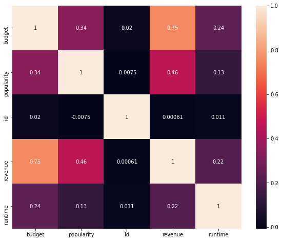

```python
train2 = train[['budget','popularity','id','revenue','runtime']]
f,ax = plt.subplots(figsize=(10, 8))
sns.heatmap(train2.corr(), annot=True)
plt.show()
```

# 數值處理範例: budget

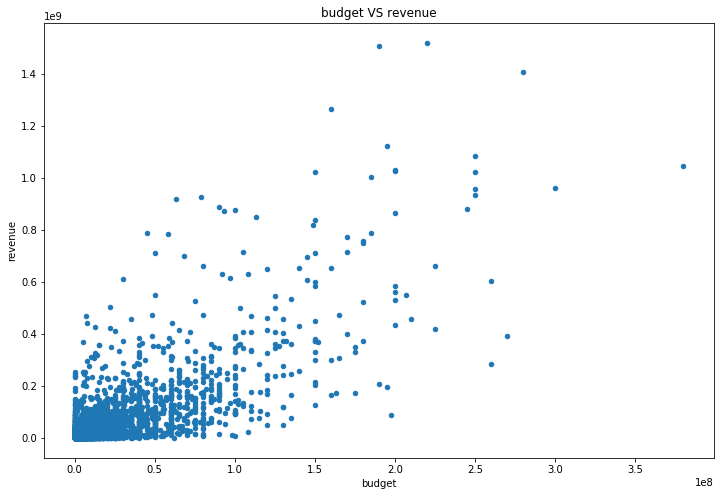

```python
train.plot(x='budget', y='revenue', kind='scatter', figsize = (12, 8) , title = 'budget VS revenue')
```

結論:

```
預算與收入關聯性較高，可見電影公司在製作電影時有較多的預算除了能打造出受觀眾喜愛的電影，也可將資源投入更多宣傳。
```

# 依真實資料補值處理範例 :

補入上網查詢後錯誤的異常值 : (資料來源:https://www.kaggle.com/zero92/tmdb-prediction)

```python
train.loc[train['id'] == 16,'revenue'] = 192864
train.loc[train['id'] == 90,'budget'] = 30000000
train.loc[train['id'] == 118,'budget'] = 60000000
train.loc[train['id'] == 149,'budget'] = 18000000
train.loc[train['id'] == 313,'revenue'] = 12000000
train.loc[train['id'] == 451,'revenue'] = 12000000
train.loc[train['id'] == 464,'budget'] = 20000000
train.loc[train['id'] == 470,'budget'] = 13000000
train.loc[train['id'] == 513,'budget'] = 930000
train.loc[train['id'] == 797,'budget'] = 8000000
train.loc[train['id'] == 819,'budget'] = 90000000
train.loc[train['id'] == 850,'budget'] = 90000000
train.loc[train['id'] == 1112,'budget'] = 7500000
train.loc[train['id'] == 1131,'budget'] = 4300000
train.loc[train['id'] == 1359,'budget'] = 10000000
train.loc[train['id'] == 1570,'budget'] = 15800000
train.loc[train['id'] == 1571,'budget'] = 4000000
train.loc[train['id'] == 1714,'budget'] = 46000000
train.loc[train['id'] == 1721,'budget'] = 17500000
train.loc[train['id'] == 1865,'revenue'] = 25000000
train.loc[train['id'] == 2268,'budget'] = 17500000
train.loc[train['id'] == 2602,'budget'] = 31000000
train.loc[train['id'] == 2612,'budget'] = 15000000
train.loc[train['id'] == 2696,'budget'] = 10000000
train.loc[train['id'] == 2801,'budget'] = 10000000
```

# 欄位分為有跟無的處理範例 : belongs_to_collection

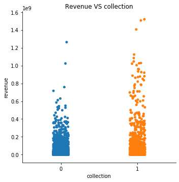

```python
train['collection'] = 0
train.loc[train['belongs_to_collection'].isnull() == False, 'collection'] = 1

sns.catplot(x='collection', y='revenue', data = train);
plt.title('Revenue VS collection');
```

結論:

```
可以發現有系列的電影收入相對比無系列的多,可能是在有系列的電影中,有累積了一定的粉絲。
```

# 字串範例 : release_date

```python
train['release_date'].head(5)
```

```
0     2/20/15
1      8/6/04
2    10/10/14
3      3/9/12
4      2/5/09
Name: release_date, dtype: object
```

```python
train[['release_month','release_day','release_year']]=train['release_date'].str.split('/',expand=True).replace(np.nan, -1).astype(int)
train.loc[ (train['release_year'] <= 19) & (train['release_year'] < 100), "release_year"] += 2000
train.loc[ (train['release_year'] > 19)  & (train['release_year'] < 100), "release_year"] += 1900

releaseDate = pd.to_datetime(train['release_date'])
train['release_dayofweek'] = releaseDate.dt.dayofweek
train['release_quarter'] = releaseDate.dt.quarter
train['release_dayofweek'] = train['release_dayofweek']+1
```

```python
train.iloc[:,-5:].head()
```

|  | release_month | release_day | release_year | release_dayofweek | release_quarter |
| --- | --- | --- | --- | --- | --- |
| 0 | 2 | 20 | 2015 | 5 | 1 |
| 1 | 8 | 6 | 2004 | 5 | 3 |
| 2 | 10 | 10 | 2014 | 5 | 4 |
| 3 | 3 | 9 | 2012 | 5 | 1 |
| 4 | 2 | 5 | 2009 | 4 | 1 |

電影數量加總:

```python
Top_year = train["release_year"].value_counts().rename_axis('year').to_frame('counts')
Top_year.head(5)
```

| year | counts |
| --- | --- |
| 2013 | 141 |
| 2015 | 128 |
| 2010 | 126 |
| 2016 | 125 |
| 2012 | 125 |

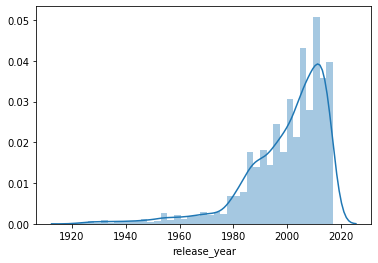

```python
sns.distplot(train["release_year"])
```

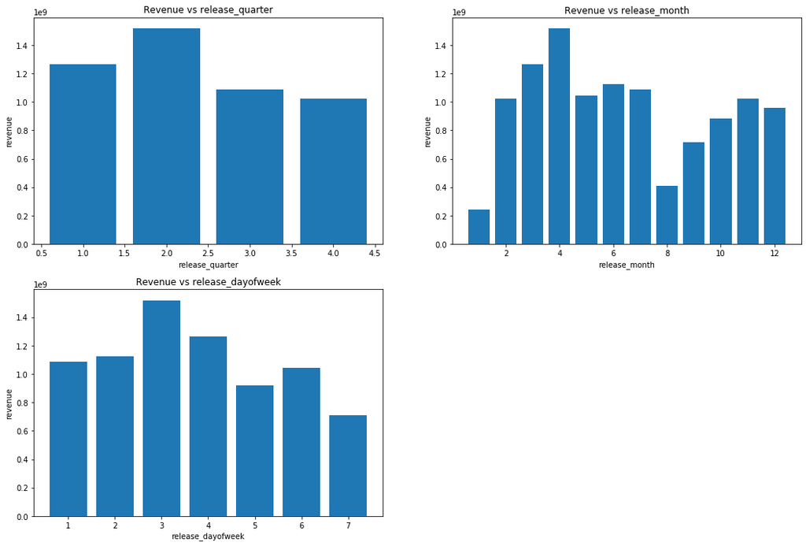

```python
plt.figure(figsize=(18, 12))
plt.subplot(2, 2, 1)
plt.xlabel('release_quarter')
plt.ylabel('revenue')
plt.bar(train['release_quarter'], train['revenue'])
plt.title('Revenue vs release_quarter');
plt.subplot(2, 2, 2)
plt.xlabel('release_month')
plt.ylabel('revenue')
plt.bar((train['release_month']), train['revenue'])
plt.title('Revenue vs release_month')
plt.subplot(2, 2, 3)
plt.xlabel('release_dayofweek')
plt.ylabel('revenue')
plt.bar((train['release_dayofweek']), train['revenue'])
plt.title('Revenue vs release_dayofweek')
```

結論:

[output not shown]

# JSON範例 : genres

```python
train['genres']
```

```
0                          [{'id': 35, 'name': 'Comedy'}]
1       [{'id': 35, 'name': 'Comedy'}, {'id': 18, 'nam...
2                           [{'id': 18, 'name': 'Drama'}]
3       [{'id': 53, 'name': 'Thriller'}, {'id': 18, 'n...
4       [{'id': 28, 'name': 'Action'}, {'id': 53, 'nam...
5       [{'id': 16, 'name': 'Animation'}, {'id': 12, '...
6       [{'id': 27, 'name': 'Horror'}, {'id': 53, 'nam...
7                     [{'id': 99, 'name': 'Documentary'}]
8       [{'id': 28, 'name': 'Action'}, {'id': 35, 'nam...
9       [{'id': 35, 'name': 'Comedy'}, {'id': 10402, '...
10                          [{'id': 18, 'name': 'Drama'}]
11                         [{'id': 35, 'name': 'Comedy'}]
12                          [{'id': 18, 'name': 'Drama'}]
13      [{'id': 35, 'name': 'Comedy'}, {'id': 80, 'nam...
14      [{'id': 28, 'name': 'Action'}, {'id': 53, 'nam...
```

[output cut: 37 more lines]

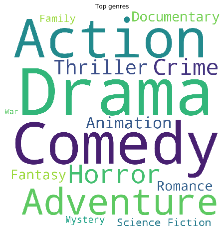

```
OrderedDict([('TV Movie', 1),
             ('Foreign', 2),
             ('Western', 13),
             ('History', 16),
             ('War', 20),
             ('Music', 20),
             ('Mystery', 33),
             ('Family', 36),
             ('Science Fiction', 41),
             ('Romance', 67),
             ('Fantasy', 68),
             ('Documentary', 71),
             ('Animation', 76),
             ('Thriller', 116),
             ('Crime', 147),
             ('Horror', 170),
             ('Adventure', 187),
             ('Action', 520),
             ('Comedy', 604),
             ('Drama', 785)])
```

```python
#將genres的name值返回成1並加總
genres = {}
for i in train['genres']:
    if (not (pd.isnull(i))):

        if (eval(i)[0]['name']) not in genres:
            genres[eval(i)[0]['name']] = 1
        else:
            genres[eval(i)[0]['name']] += 1
#設定畫圖尺寸
plt.figure(figsize=(12, 8))
#創建詞雲圖
wordcloud = WordCloud(background_color="white", #設定背景顏色
                      width=1000, height=1000, #設定寬度與高度
                      max_words=15, #設定最大字的尺寸
                      relative_scaling=0.5, #字體大小的相對字頻率的比率
                      normalize_plurals=False #是否從單詞中刪除尾隨's'
                     ).generate_from_frequencies(genres)
#對產生出來的wordcloud圖檔進行繪製，再返回一个matplotlib類型的資料
plt.imshow(wordcloud)
#設定標題
plt.title('Top genres')
#不顯示軸線
plt.axis("off")
#顯示
plt.show()
#OrderedDict可以對字典對象中元素的排序
genres = OrderedDict(genres)
#由少至多排序出現字串的次數
OrderedDict(sorted(genres.items(), key=lambda t: t[1]))
```

# 出現最多次類型的分別為: Drama(戲劇類),Comedy(喜劇類),Action(動作類)

# genres匯入模型特徵工程範例:

```python
import ast
for c in ['genres']:
    train[c] = train[c].apply(lambda x: {} if pd.isna(x) else ast.literal_eval(x))
```

```python
list_of_genres = list(train['genres'].apply(lambda x: [i['name'] for i in x] if x != {} else []).values)
print(list_of_genres[:10])
```

```
[['Comedy'], ['Comedy', 'Drama', 'Family', 'Romance'], ['Drama'], ['Thriller', 'Drama'], ['Action', 'Thriller'], ['Animation', 'Adventure', 'Family'], ['Horror', 'Thriller'], ['Documentary'], ['Action', 'Comedy', 'Music', 'Family', 'Adventure'], ['Comedy', 'Music']]
```

```python
train['num_genres'] = train['genres'].apply(lambda x: len(x) if x != {} else 0)
#把所有genres後面的name值取出
train['all_genres'] = train['genres'].apply(lambda x: ' '.join(([i['name'] for i in x])) if x != {} else '')
print(train['num_genres'][:15])
```

```
0     1
1     4
2     1
3     2
4     2
5     3
6     2
7     1
8     5
9     2
10    1
11    1
12    1
13    2
14    4
Name: num_genres, dtype: int64
```

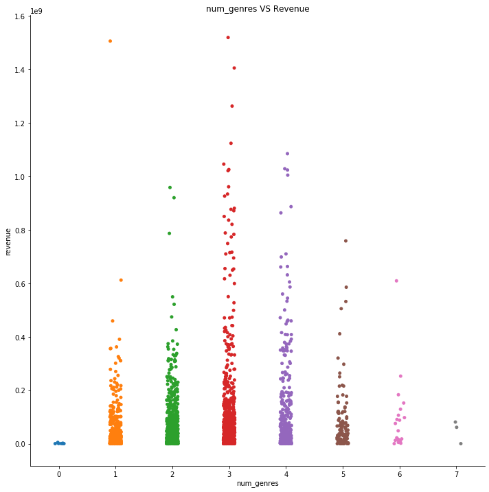

```python
sns.catplot(x='num_genres', y='revenue', data = train , height = 10);
plt.title('num_genres VS Revenue');
```

可以看到一部電影中,出現3次類型的收入普遍較多,所以適當的豐富電影總類,也是觀眾們的需求。

```python
top_genres = [m[0] for m in Counter([i for j in list_of_genres for i in j]).most_common(20)]
print(top_genres)
#把上一個前20項的字詞新增為各個欄位,假如top_genres的字詞有出現在all_genres裡,該欄位為1
for g in top_genres:
    train['genres_' + g] = train['all_genres'].apply(lambda x: 1 if g in x else 0)
```

```
['Drama', 'Comedy', 'Thriller', 'Action', 'Romance', 'Crime', 'Adventure', 'Horror', 'Science Fiction', 'Family', 'Fantasy', 'Mystery', 'Animation', 'History', 'Music', 'War', 'Documentary', 'Western', 'Foreign', 'TV Movie']
```

```python
#創建一個只有id及revenue的表格
top_genresdf=pd.DataFrame()
top_genresdf['id']=train['id']
top_genresdf['revenue']=train['revenue']
```

```python
#創建新的表格並只篩選train的第23行到最後一行的欄位
top_genresdf2 = train.iloc[:,25:]
#索引值加入revenue
top_genresdf2.index=train['revenue']
#display可以將所有欄位完全顯示不中斷
pd.options.display.max_columns = None
```

```python
top_genresdf3 = top_genresdf.merge(top_genresdf2, left_on = 'revenue', right_on = 'revenue', how = 'left')
#顯示並將revenue值排序(由大到小)
tt = top_genresdf3.sort_values(['revenue'], ascending=False)
```

```python
tt.head()
```

|  | id | revenue | release_day | release_year | release_dayofweek | release_quarter | num_genres | all_genres | genres_Drama | genres_Comedy | genres_Thriller | genres_Action | genres_Romance | genres_Crime | genres_Adventure | genres_Horror | genres_Science Fiction | genres_Family | genres_Fantasy | genres_Mystery | genres_Animation | genres_History | genres_Music | genres_War | genres_Documentary | genres_Western | genres_Foreign | genres_TV Movie |
| --- | --- | --- | --- | --- | --- | --- | --- | --- | --- | --- | --- | --- | --- | --- | --- | --- | --- | --- | --- | --- | --- | --- | --- | --- | --- | --- | --- | --- |
| 1412 | 1127 | 1519557910 | 25 | 2012 | 3 | 2 | 3 | Science Fiction Action Adventure | 0 | 0 | 0 | 1 | 0 | 0 | 1 | 0 | 1 | 0 | 0 | 0 | 0 | 0 | 0 | 0 | 0 | 0 | 0 | 0 |
| 2190 | 1762 | 1506249360 | 1 | 2015 | 3 | 2 | 1 | Action | 0 | 0 | 0 | 1 | 0 | 0 | 0 | 0 | 0 | 0 | 0 | 0 | 0 | 0 | 0 | 0 | 0 | 0 | 0 | 0 |
| 3462 | 2771 | 1405403694 | 22 | 2015 | 3 | 2 | 3 | Action Adventure Science Fiction | 0 | 0 | 0 | 1 | 0 | 0 | 1 | 0 | 1 | 0 | 0 | 0 | 0 | 0 | 0 | 0 | 0 | 0 | 0 | 0 |
| 889 | 685 | 1262886337 | 16 | 2017 | 4 | 1 | 3 | Family Fantasy Romance | 0 | 0 | 0 | 0 | 1 | 0 | 0 | 0 | 0 | 1 | 1 | 0 | 0 | 0 | 0 | 0 | 0 | 0 | 0 | 0 |
| 2892 | 2323 | 1123746996 | 28 | 2011 | 2 | 2 | 3 | Action Science Fiction Adventure | 0 | 0 | 0 | 1 | 0 | 0 | 1 | 0 | 1 | 0 | 0 | 0 | 0 | 0 | 0 | 0 | 0 | 0 | 0 | 0 |

# 收入(revenue)前100的前3名出現類型(genures)

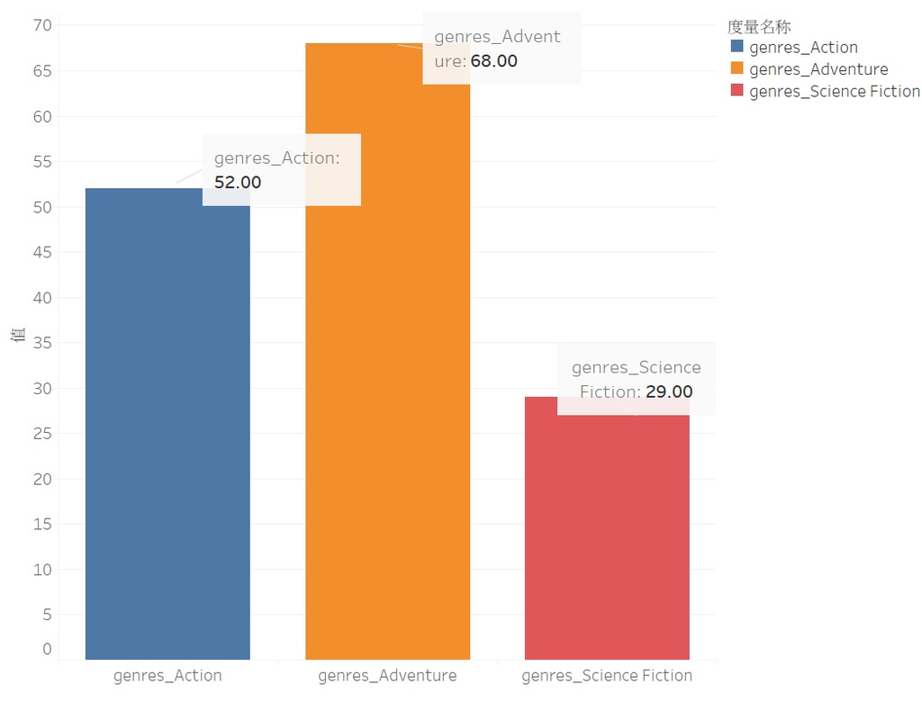

結論:

```
 可以看到Adventure(冒險),Action(動作),Science Fiction(科幻小說),是能得到最多收入的3大類,與出現最多的前3類型有所不同,這即是從資料分析中獲得的隱藏資訊,故可以供製片團隊做拍攝往後的拍片類型參考!
```

```python
train = pd.read_csv('train.csv')
test = pd.read_csv('test.csv')
```

# 外部資料匯入 :

```python
trainAdditionalFeatures = pd.read_csv('TrainAdditionalFeatures.csv')[['imdb_id','popularity2','rating']]
testAdditionalFeatures = pd.read_csv('TestAdditionalFeatures.csv')[['imdb_id','popularity2','rating']]
train = pd.merge(train, trainAdditionalFeatures, how='left', on=['imdb_id'], right_index  = True)
test = pd.merge(test, testAdditionalFeatures, how='left', on=['imdb_id'], right_index  = True)

vote = pd.read_csv('external_tmdbmovies.csv')[["vote_count","vote_average"]]
vote['id'] = range(1,4804)
vote.index = vote['id']
vote.drop('id',axis = 1,inplace = True)
train = pd.merge(train, vote, how='left', on=['id'])
test = pd.merge(test, vote, how='left', on=['id'])

release_dates = pd.read_csv('release_dates_per_country.csv')
release_dates['id'] = range(1,7399)
release_dates.drop(['original_title','title'],axis = 1,inplace = True)
release_dates.index = release_dates['id']

release_dates.drop('id',axis = 1,inplace = True)
train = pd.merge(train, release_dates, how='left', on=['id'])
test = pd.merge(test, release_dates, how='left', on=['id'])
```

```python
train.head()
```

|  | id | belongs_to_collection | budget | genres | homepage | imdb_id | original_language | original_title | overview | popularity | poster_path | production_companies | production_countries | release_date | runtime | spoken_languages | status | tagline | title | Keywords | cast | crew | revenue | popularity2 | rating | vote_count | vote_average | release_year | movie_id | … |
| --- | --- | --- | --- | --- | --- | --- | --- | --- | --- | --- | --- | --- | --- | --- | --- | --- | --- | --- | --- | --- | --- | --- | --- | --- | --- | --- | --- | --- | --- | --- |
| 0 | 1 | [{'id': 313576, 'name': 'Hot Tub Time Machine ... | 14000000 | [{'id': 35, 'name': 'Comedy'}] | NaN | tt2637294 | en | Hot Tub Time Machine 2 | When Lou, who has become the "father of the In... | 6.575393 | /tQtWuwvMf0hCc2QR2tkolwl7c3c.jpg | [{'name': 'Paramount Pictures', 'id': 4}, {'na... | [{'iso_3166_1': 'US', 'name': 'United States o... | 2/20/15 | 93.0 | [{'iso_639_1': 'en', 'name': 'English'}] | Released | The Laws of Space and Time are About to be Vio... | Hot Tub Time Machine 2 | [{'id': 4379, 'name': 'time travel'}, {'id': 9... | [{'cast_id': 4, 'character': 'Lou', 'credit_id... | [{'credit_id': '59ac067c92514107af02c8c8', 'de... | 12314651 | NaN | NaN | 11800 | 7.2 | 2015 | 243938 | … |
| 1 | 2 | [{'id': 107674, 'name': 'The Princess Diaries ... | 40000000 | [{'id': 35, 'name': 'Comedy'}, {'id': 18, 'nam... | NaN | tt0368933 | en | The Princess Diaries 2: Royal Engagement | Mia Thermopolis is now a college graduate and ... | 8.248895 | /w9Z7A0GHEhIp7etpj0vyKOeU1Wx.jpg | [{'name': 'Walt Disney Pictures', 'id': 2}] | [{'iso_3166_1': 'US', 'name': 'United States o... | 8/6/04 | 113.0 | [{'iso_639_1': 'en', 'name': 'English'}] | Released | It can take a lifetime to find true love; she'... | The Princess Diaries 2: Royal Engagement | [{'id': 2505, 'name': 'coronation'}, {'id': 42... | [{'cast_id': 1, 'character': 'Mia Thermopolis'... | [{'credit_id': '52fe43fe9251416c7502563d', 'de... | 95149435 | NaN | NaN | 4500 | 6.9 | 2004 | 11130 | … |
| 2 | 3 | NaN | 3300000 | [{'id': 18, 'name': 'Drama'}] | http://sonyclassics.com/whiplash/ | tt2582802 | en | Whiplash | Under the direction of a ruthless instructor, ... | 64.299990 | /lIv1QinFqz4dlp5U4lQ6HaiskOZ.jpg | [{'name': 'Bold Films', 'id': 2266}, {'name': ... | [{'iso_3166_1': 'US', 'name': 'United States o... | 10/10/14 | 105.0 | [{'iso_639_1': 'en', 'name': 'English'}] | Released | The road to greatness can take you to the edge. | Whiplash | [{'id': 1416, 'name': 'jazz'}, {'id': 1523, 'n... | [{'cast_id': 5, 'character': 'Andrew Neimann',... | [{'credit_id': '54d5356ec3a3683ba0000039', 'de... | 13092000 | NaN | NaN | 4466 | 6.3 | 2014 | 244786 | … |
| 3 | 4 | NaN | 1200000 | [{'id': 53, 'name': 'Thriller'}, {'id': 18, 'n... | http://kahaanithefilm.com/ | tt1821480 | hi | Kahaani | Vidya Bagchi (Vidya Balan) arrives in Kolkata ... | 3.174936 | /aTXRaPrWSinhcmCrcfJK17urp3F.jpg | NaN | [{'iso_3166_1': 'IN', 'name': 'India'}] | 3/9/12 | 122.0 | [{'iso_639_1': 'en', 'name': 'English'}, {'iso... | Released | NaN | Kahaani | [{'id': 10092, 'name': 'mystery'}, {'id': 1054... | [{'cast_id': 1, 'character': 'Vidya Bagchi', '... | [{'credit_id': '52fe48779251416c9108d6eb', 'de... | 16000000 | NaN | NaN | 9106 | 7.6 | 2012 | 82825 | … |
| 4 | 5 | NaN | 0 | [{'id': 28, 'name': 'Action'}, {'id': 53, 'nam... | NaN | tt1380152 | ko | 마린보이 | Marine Boy is the story of a former national s... | 1.148070 | /m22s7zvkVFDU9ir56PiiqIEWFdT.jpg | NaN | [{'iso_3166_1': 'KR', 'name': 'South Korea'}] | 2/5/09 | 118.0 | [{'iso_639_1': 'ko', 'name': '한국어/조선말'}] | Released | NaN | Marine Boy | NaN | [{'cast_id': 3, 'character': 'Chun-soo', 'cred... | [{'credit_id': '52fe464b9251416c75073b43', 'de... | 3923970 | NaN | NaN | 2124 | 6.1 | 2009 | 15286 | … |

# 迴歸模型計算指標:

```python
def rmse(y, y_pred):
    return np.sqrt(mean_squared_error(y, y_pred))
```

# 特徵工程 :

例: 收入-預算*100 = 收益率 ， 預算/電影時間 = 單位成本 ， 上映年份/平均預算 = 每年平均預算...等)

```python
def prepare(df):
    global json_cols
    global train_dict
    #df['totalVotes'] = df['totalVotes'].fillna(6)

    df[['release_month','release_day','release_year']]=df['release_date'].str.split('/',expand=True).replace(np.nan, 0).astype(int)
    df['release_year'] = df['release_year']
    df.loc[ (df['release_year'] <= 18) & (df['release_year'] < 100), "release_year"] += 2000
    df.loc[ (df['release_year'] > 18)  & (df['release_year'] < 100), "release_year"] += 1900

    rating_na = df.groupby(["release_year","original_language"])['rating'].mean().reset_index()
    df[df.rating.isna()]['rating'] = df.merge(rating_na, how = 'left' ,on = ["release_year","original_language"])

    vote_count_na = df.groupby(["release_year","original_language"])['vote_count'].mean().reset_index()
    df[df.vote_count.isna()]['vote_count'] = df.merge(vote_count_na, how = 'left' ,on = ["release_year","original_language"])

    #budget_na = df.groupby(["release_year","original_language"])['budget'].mean().reset_index()
    #df.loc[df.budget == 0]['budget'] = df.merge(budget_na, how = 'left' ,on = ["release_year","original_language"])

    df['budget'] = np.log1p(df['budget'])

    df['genders_0_crew'] = df['crew'].apply(lambda x: sum([1 for i in x if i['gender'] == 0]))
    df['genders_1_crew'] = df['crew'].apply(lambda x: sum([1 for i in x if i['gender'] == 1]))
    df['genders_2_crew'] = df['crew'].apply(lambda x: sum([1 for i in x if i['gender'] == 2]))


    df['_collection_name'] = df['belongs_to_collection'].apply(lambda x: x[0]['name'] if x != {} else 0)
    le = LabelEncoder()
    le.fit(list(df['_collection_name'].fillna('')))
    df['_collection_name'] = le.transform(df['_collection_name'].fillna('').astype(str))
    df['_num_Keywords'] = df['Keywords'].apply(lambda x: len(x) if x != {} else 0)
    df['_num_cast'] = df['cast'].apply(lambda x: len(x) if x != {} else 0)

    releaseDate = pd.to_datetime(df['release_date'])
    df['release_dayofweek'] = releaseDate.dt.dayofweek
    df['release_quarter'] = releaseDate.dt.quarter

    df['_budget_runtime_ratio'] = df['budget']/df['runtime']
    df['_budget_popularity_ratio'] = df['budget']/df['popularity']
    df['_budget_year_ratio'] = df['budget']/(df['release_year']*df['release_year'])
    df['_releaseYear_popularity_ratio'] = df['release_year']/df['popularity']
    df['_releaseYear_popularity_ratio2'] = df['popularity']/df['release_year']


    df['meanruntimeByYear'] = df.groupby("release_year")["runtime"].aggregate('mean')
    df['meanPopularityByYear'] = df.groupby("release_year")["popularity"].aggregate('mean')
    df['meanBudgetByYear'] = df.groupby("release_year")["budget"].aggregate('mean')
    df['_popularity_theatrical_ratio'] = df['theatrical']/df['popularity']
    df['_budget_theatrical_ratio'] = df['budget']/df['theatrical']
    #df['mean_theatrical_ByYear'] = df.groupby("release_year")["theatrical"].aggregate('mean')
    df['_popularity_totalVotes_ratio'] = df['vote_count']/df['popularity']
    df['_totalVotes_releaseYear_ratio'] = df['vote_count']/df['release_year']
    df['_budget_totalVotes_ratio'] = df['budget']/df['vote_count']


    df['_rating_popularity_ratio'] = df['rating']/df['popularity']
    df['_rating_totalVotes_ratio'] = df['vote_count']/df['rating']
    df['_budget_rating_ratio'] = df['budget']/df['rating']
    df['_runtime_rating_ratio'] = df['runtime']/df['rating']


    df['has_homepage'] = 0
    df.loc[pd.isnull(df['homepage']) ,"has_homepage"] = 1

    df['isbelongs_to_collectionNA'] = 0
    df.loc[pd.isnull(df['belongs_to_collection']) ,"isbelongs_to_collectionNA"] = 1

    df['isTaglineNA'] = 0
    df.loc[df['tagline'] == 0 ,"isTaglineNA"] = 1

    df['isOriginalLanguageEng'] = 0
    df.loc[ df['original_language'] == "en" ,"isOriginalLanguageEng"] = 1

    df['isTitleDifferent'] = 1
    df.loc[ df['original_title'] == df['title'] ,"isTitleDifferent"] = 0

    df['isMovieReleased'] = 1
    df.loc[ df['status'] != "Released" ,"isMovieReleased"] = 0

    # get collection id
    df['collection_id'] = df['belongs_to_collection'].apply(lambda x : np.nan if len(x)==0 else x[0]['id'])

    df['original_title_letter_count'] = df['original_title'].str.len()
    df['original_title_word_count'] = df['original_title'].str.split().str.len()


    df['title_word_count'] = df['title'].str.split().str.len()
    df['overview_word_count'] = df['overview'].str.split().str.len()
    df['tagline_word_count'] = df['tagline'].str.split().str.len()

    df['production_countries_count'] = df['production_countries'].apply(lambda x : len(x))
    df['production_companies_count'] = df['production_companies'].apply(lambda x : len(x))
    df['cast_count'] = df['cast'].apply(lambda x : len(x))
    df['crew_count'] = df['crew'].apply(lambda x : len(x))




    for col in ['genres', 'production_countries', 'spoken_languages', 'production_companies'] :
        df[col] = df[col].map(lambda x: sorted(list(set([n if n in train_dict[col] else col+'_etc' for n in [d['name'] for d in x]])))).map(lambda x: ','.join(map(str, x)))
        temp = df[col].str.get_dummies(sep=',')
        df = pd.concat([df, temp], axis=1, sort=False)
    df.drop(['genres_etc'], axis = 1, inplace = True)

    df = df.drop(['belongs_to_collection','genres','homepage','imdb_id','overview','runtime'
    ,'poster_path','production_companies','production_countries','release_date','spoken_languages'
    ,'status','title','Keywords','cast','crew','original_language','original_title','tagline', 'collection_id','movie_id'
    ],axis=1)

    df.fillna(value=0.0, inplace = True)

    return df
```

```python
test['revenue'] = np.nan

json_cols = ['genres', 'production_companies', 'production_countries', 'spoken_languages', 'Keywords', 'cast', 'crew']

def get_dictionary(s):
    try:
        d = eval(s)
    except:
        d = {}
    return d

for col in tqdm(json_cols + ['belongs_to_collection']) :
    train[col] = train[col].apply(lambda x : get_dictionary(x))
    test[col] = test[col].apply(lambda x : get_dictionary(x))
train.head()
```

|  | id | belongs_to_collection | budget | genres | homepage | imdb_id | original_language | original_title | overview | popularity | poster_path | production_companies | production_countries | release_date | runtime | spoken_languages | status | tagline | title | Keywords | cast | crew | revenue | popularity2 | rating | vote_count | vote_average | release_year | movie_id | … |
| --- | --- | --- | --- | --- | --- | --- | --- | --- | --- | --- | --- | --- | --- | --- | --- | --- | --- | --- | --- | --- | --- | --- | --- | --- | --- | --- | --- | --- | --- | --- |
| 0 | 1 | [{'id': 313576, 'name': 'Hot Tub Time Machine ... | 14000000 | [{'id': 35, 'name': 'Comedy'}] | NaN | tt2637294 | en | Hot Tub Time Machine 2 | When Lou, who has become the "father of the In... | 6.575393 | /tQtWuwvMf0hCc2QR2tkolwl7c3c.jpg | [{'name': 'Paramount Pictures', 'id': 4}, {'na... | [{'iso_3166_1': 'US', 'name': 'United States o... | 2/20/15 | 93.0 | [{'iso_639_1': 'en', 'name': 'English'}] | Released | The Laws of Space and Time are About to be Vio... | Hot Tub Time Machine 2 | [{'id': 4379, 'name': 'time travel'}, {'id': 9... | [{'cast_id': 4, 'character': 'Lou', 'credit_id... | [{'credit_id': '59ac067c92514107af02c8c8', 'de... | 12314651 | NaN | NaN | 11800 | 7.2 | 2015 | 243938 | … |
| 1 | 2 | [{'id': 107674, 'name': 'The Princess Diaries ... | 40000000 | [{'id': 35, 'name': 'Comedy'}, {'id': 18, 'nam... | NaN | tt0368933 | en | The Princess Diaries 2: Royal Engagement | Mia Thermopolis is now a college graduate and ... | 8.248895 | /w9Z7A0GHEhIp7etpj0vyKOeU1Wx.jpg | [{'name': 'Walt Disney Pictures', 'id': 2}] | [{'iso_3166_1': 'US', 'name': 'United States o... | 8/6/04 | 113.0 | [{'iso_639_1': 'en', 'name': 'English'}] | Released | It can take a lifetime to find true love; she'... | The Princess Diaries 2: Royal Engagement | [{'id': 2505, 'name': 'coronation'}, {'id': 42... | [{'cast_id': 1, 'character': 'Mia Thermopolis'... | [{'credit_id': '52fe43fe9251416c7502563d', 'de... | 95149435 | NaN | NaN | 4500 | 6.9 | 2004 | 11130 | … |
| 2 | 3 | {} | 3300000 | [{'id': 18, 'name': 'Drama'}] | http://sonyclassics.com/whiplash/ | tt2582802 | en | Whiplash | Under the direction of a ruthless instructor, ... | 64.299990 | /lIv1QinFqz4dlp5U4lQ6HaiskOZ.jpg | [{'name': 'Bold Films', 'id': 2266}, {'name': ... | [{'iso_3166_1': 'US', 'name': 'United States o... | 10/10/14 | 105.0 | [{'iso_639_1': 'en', 'name': 'English'}] | Released | The road to greatness can take you to the edge. | Whiplash | [{'id': 1416, 'name': 'jazz'}, {'id': 1523, 'n... | [{'cast_id': 5, 'character': 'Andrew Neimann',... | [{'credit_id': '54d5356ec3a3683ba0000039', 'de... | 13092000 | NaN | NaN | 4466 | 6.3 | 2014 | 244786 | … |
| 3 | 4 | {} | 1200000 | [{'id': 53, 'name': 'Thriller'}, {'id': 18, 'n... | http://kahaanithefilm.com/ | tt1821480 | hi | Kahaani | Vidya Bagchi (Vidya Balan) arrives in Kolkata ... | 3.174936 | /aTXRaPrWSinhcmCrcfJK17urp3F.jpg | {} | [{'iso_3166_1': 'IN', 'name': 'India'}] | 3/9/12 | 122.0 | [{'iso_639_1': 'en', 'name': 'English'}, {'iso... | Released | NaN | Kahaani | [{'id': 10092, 'name': 'mystery'}, {'id': 1054... | [{'cast_id': 1, 'character': 'Vidya Bagchi', '... | [{'credit_id': '52fe48779251416c9108d6eb', 'de... | 16000000 | NaN | NaN | 9106 | 7.6 | 2012 | 82825 | … |
| 4 | 5 | {} | 0 | [{'id': 28, 'name': 'Action'}, {'id': 53, 'nam... | NaN | tt1380152 | ko | 마린보이 | Marine Boy is the story of a former national s... | 1.148070 | /m22s7zvkVFDU9ir56PiiqIEWFdT.jpg | {} | [{'iso_3166_1': 'KR', 'name': 'South Korea'}] | 2/5/09 | 118.0 | [{'iso_639_1': 'ko', 'name': '한국어/조선말'}] | Released | NaN | Marine Boy | {} | [{'cast_id': 3, 'character': 'Chun-soo', 'cred... | [{'credit_id': '52fe464b9251416c75073b43', 'de... | 3923970 | NaN | NaN | 2124 | 6.1 | 2009 | 15286 | … |

# 去除不必要欄位:

```python
def get_json_dict(df) :
    global json_cols
    result = dict()
    for e_col in json_cols :
        d = dict()
        rows = df[e_col].values
        for row in rows :
            if row is None : continue
            for i in row :
                if i['name'] not in d :
                    d[i['name']] = 0
                d[i['name']] += 1
        result[e_col] = d
    return result

train_dict = get_json_dict(train)
test_dict = get_json_dict(test)

# remove cateogry with bias and low frequency
for col in json_cols :

    remove = []
    train_id = set(list(train_dict[col].keys()))
    test_id = set(list(test_dict[col].keys()))

    remove += list(train_id - test_id) + list(test_id - train_id)
    for i in train_id.union(test_id) - set(remove) :
        if train_dict[col][i] < 10 or i == '' :
            remove += [i]

    for i in remove :
        if i in train_dict[col] :
            del train_dict[col][i]
        if i in test_dict[col] :
            del test_dict[col][i]

    print(col, 'size :', len(train_id.union(test_id)), '->', len(train_dict[col]))
```

```
genres size : 20 -> 19
production_companies size : 7087 -> 77
production_countries size : 98 -> 25
spoken_languages size : 64 -> 27
Keywords size : 11930 -> 358
cast size : 75944 -> 376
crew size : 68763 -> 516
```

# 最後的總特徵數:

```python
all_data = prepare(pd.concat([train, test]).reset_index(drop = False))
train = all_data.loc[:train.shape[0] - 1,:]
test = all_data.loc[train.shape[0]:,:]
print(train.shape)
train.head()
```

```
(3000, 244)
```

|  | index | AR | AT | AU | BE | BG | CA | CL | CZ | DE | DK | FI | FR | GB | GR | HK | HU | ID | IE | IL | IS | IT | KW | KZ | LV | MX | NL | NO | PE | … |
| --- | --- | --- | --- | --- | --- | --- | --- | --- | --- | --- | --- | --- | --- | --- | --- | --- | --- | --- | --- | --- | --- | --- | --- | --- | --- | --- | --- | --- | --- | --- |
| 0 | 0 | 0.0 | 0.0 | 0.0 | 0.0 | 0.0 | 1.0 | 0.0 | 0.0 | 0.0 | 0.0 | 0.0 | 0.0 | 1.0 | 0.0 | 0.0 | 0.0 | 0.0 | 0.0 | 0.0 | 0.0 | 1.0 | 0.0 | 0.0 | 0.0 | 0.0 | 0.0 | 0.0 | 0.0 | … |
| 1 | 1 | 0.0 | 0.0 | 1.0 | 0.0 | 0.0 | 1.0 | 0.0 | 0.0 | 1.0 | 0.0 | 0.0 | 1.0 | 1.0 | 0.0 | 0.0 | 0.0 | 0.0 | 0.0 | 1.0 | 0.0 | 1.0 | 0.0 | 0.0 | 0.0 | 0.0 | 0.0 | 1.0 | 0.0 | … |
| 2 | 2 | 0.0 | 0.0 | 1.0 | 1.0 | 0.0 | 1.0 | 0.0 | 1.0 | 1.0 | 1.0 | 1.0 | 1.0 | 1.0 | 1.0 | 1.0 | 0.0 | 0.0 | 1.0 | 1.0 | 1.0 | 1.0 | 0.0 | 0.0 | 0.0 | 0.0 | 1.0 | 0.0 | 0.0 | … |
| 3 | 3 | 0.0 | 0.0 | 0.0 | 0.0 | 0.0 | 1.0 | 0.0 | 0.0 | 0.0 | 0.0 | 0.0 | 0.0 | 0.0 | 0.0 | 0.0 | 0.0 | 0.0 | 0.0 | 0.0 | 0.0 | 0.0 | 1.0 | 0.0 | 0.0 | 0.0 | 0.0 | 0.0 | 0.0 | … |
| 4 | 4 | 0.0 | 0.0 | 0.0 | 0.0 | 0.0 | 0.0 | 0.0 | 0.0 | 0.0 | 0.0 | 0.0 | 0.0 | 0.0 | 0.0 | 0.0 | 0.0 | 0.0 | 0.0 | 0.0 | 0.0 | 0.0 | 0.0 | 0.0 | 0.0 | 0.0 | 0.0 | 0.0 | 0.0 | … |

```python
train.describe()
```

|  | index | AR | AT | AU | BE | BG | CA | CL | CZ | DE | DK | FI | FR | GB | GR | HK | HU | ID | IE | IL | IS | IT | KW | KZ | LV | MX | NL | NO | PE | … |
| --- | --- | --- | --- | --- | --- | --- | --- | --- | --- | --- | --- | --- | --- | --- | --- | --- | --- | --- | --- | --- | --- | --- | --- | --- | --- | --- | --- | --- | --- | --- |
| count | 3000.000000 | 3000.000000 | 3000.000000 | 3000.000000 | 3000.000000 | 3000.000000 | 3000.000000 | 3000.00000 | 3000.000000 | 3000.000000 | 3000.000000 | 3000.000000 | 3000.000000 | 3000.000000 | 3000.000000 | 3000.000000 | 3000.000000 | 3000.000000 | 3000.000000 | 3000.000000 | 3000.000000 | 3000.000000 | 3000.000000 | 3000.000000 | 3000.000000 | 3000.00000 | 3000.000000 | 3000.000000 | 3000.000000 | … |
| mean | 1499.500000 | 0.137333 | 0.091333 | 0.399000 | 0.136333 | 0.101667 | 0.233333 | 0.06100 | 0.156333 | 0.247667 | 0.317667 | 0.154667 | 0.588333 | 0.588667 | 0.321333 | 0.135000 | 0.186333 | 0.038667 | 0.148333 | 0.112000 | 0.089000 | 0.395333 | 0.064333 | 0.050000 | 0.024667 | 0.10300 | 0.258667 | 0.126667 | 0.051667 | … |
| std | 866.169729 | 0.344256 | 0.289286 | 0.489774 | 0.343199 | 0.302260 | 0.423811 | 0.23937 | 0.363232 | 0.431729 | 0.465647 | 0.364402 | 0.492217 | 0.492157 | 0.467066 | 0.341781 | 0.389440 | 0.192831 | 0.355489 | 0.315419 | 0.284791 | 0.489685 | 0.245387 | 0.217981 | 0.155133 | 0.30401 | 0.437975 | 0.332655 | 0.221390 | … |
| min | 0.000000 | 0.000000 | 0.000000 | 0.000000 | 0.000000 | 0.000000 | 0.000000 | 0.00000 | 0.000000 | 0.000000 | 0.000000 | 0.000000 | 0.000000 | 0.000000 | 0.000000 | 0.000000 | 0.000000 | 0.000000 | 0.000000 | 0.000000 | 0.000000 | 0.000000 | 0.000000 | 0.000000 | 0.000000 | 0.00000 | 0.000000 | 0.000000 | 0.000000 | … |
| 25% | 749.750000 | 0.000000 | 0.000000 | 0.000000 | 0.000000 | 0.000000 | 0.000000 | 0.00000 | 0.000000 | 0.000000 | 0.000000 | 0.000000 | 0.000000 | 0.000000 | 0.000000 | 0.000000 | 0.000000 | 0.000000 | 0.000000 | 0.000000 | 0.000000 | 0.000000 | 0.000000 | 0.000000 | 0.000000 | 0.00000 | 0.000000 | 0.000000 | 0.000000 | … |
| 50% | 1499.500000 | 0.000000 | 0.000000 | 0.000000 | 0.000000 | 0.000000 | 0.000000 | 0.00000 | 0.000000 | 0.000000 | 0.000000 | 0.000000 | 1.000000 | 1.000000 | 0.000000 | 0.000000 | 0.000000 | 0.000000 | 0.000000 | 0.000000 | 0.000000 | 0.000000 | 0.000000 | 0.000000 | 0.000000 | 0.00000 | 0.000000 | 0.000000 | 0.000000 | … |
| 75% | 2249.250000 | 0.000000 | 0.000000 | 1.000000 | 0.000000 | 0.000000 | 0.000000 | 0.00000 | 0.000000 | 0.000000 | 1.000000 | 0.000000 | 1.000000 | 1.000000 | 1.000000 | 0.000000 | 0.000000 | 0.000000 | 0.000000 | 0.000000 | 0.000000 | 1.000000 | 0.000000 | 0.000000 | 0.000000 | 0.00000 | 1.000000 | 0.000000 | 0.000000 | … |
| max | 2999.000000 | 1.000000 | 2.000000 | 1.000000 | 1.000000 | 1.000000 | 2.000000 | 1.00000 | 1.000000 | 1.000000 | 1.000000 | 2.000000 | 1.000000 | 1.000000 | 1.000000 | 1.000000 | 1.000000 | 1.000000 | 1.000000 | 1.000000 | 1.000000 | 2.000000 | 1.000000 | 1.000000 | 1.000000 | 1.00000 | 1.000000 | 1.000000 | 1.000000 | … |

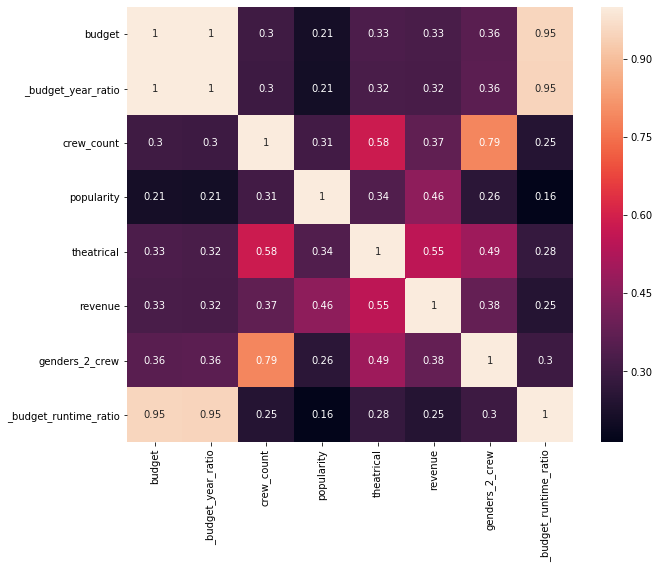

```python
train3 = train[['budget','_budget_year_ratio','crew_count','popularity','theatrical','revenue','genders_2_crew','_budget_runtime_ratio']]
f,ax = plt.subplots(figsize=(10, 8))
sns.heatmap(train3.corr(), annot=True)
plt.show()
```

# 應用模型導入:

```python
target = list(train.columns)
target =  [i for i in target if i != 'id' and i != 'revenue']
```

```python
from sklearn.metrics import mean_squared_error
def score(data, y):
    validation_res = pd.DataFrame(
    {"id": data["id"].values,
     "transactionrevenue": data["revenue"].values,
     "predictedrevenue": np.expm1(y)})

    validation_res = validation_res.groupby("id")["transactionrevenue", "predictedrevenue"].sum().reset_index()
    return np.sqrt(mean_squared_error(np.log1p(validation_res["transactionrevenue"].values),
                                     np.log1p(validation_res["predictedrevenue"].values)))
```

```python
from sklearn.model_selection import GroupKFold
#將訓練/測試資料集劃分n_splits個互斥子集，每次用n_splits-1個子集的並集作為訓練集，餘下的子集作為測試集
class KFoldValidation():
    def __init__(self, data, n_splits=3):
        unique_vis = np.array(sorted(data['id'].astype(str).unique()))
        folds = GroupKFold(n_splits)
        ids = np.arange(data.shape[0])

        self.fold_ids = []
        for trn_vis, val_vis in folds.split(X=unique_vis, y=unique_vis, groups=unique_vis):
            self.fold_ids.append([
                    ids[data['id'].astype(str).isin(unique_vis[trn_vis])],
                    ids[data['id'].astype(str).isin(unique_vis[val_vis])]
                ])

    def validate(self, train, test, features, model, name="", prepare_stacking=False,
                 fit_params={"early_stopping_rounds": 500, "verbose": 100, "eval_metric": "rmse"}):
        model.FI = pd.DataFrame(index=features)
        full_score = 0

        if prepare_stacking:
            test[name] = 0
            train[name] = np.NaN

        for fold_id, (trn, val) in enumerate(self.fold_ids):
            devel = train[features].iloc[trn]
            y_devel = np.log1p(train["revenue"].iloc[trn])
            valid = train[features].iloc[val]
            y_valid = np.log1p(train["revenue"].iloc[val])

            print("Fold ", fold_id, ":")
            model.fit(devel, y_devel, eval_set=[(valid, y_valid)], **fit_params)

            if len(model.feature_importances_) == len(features):  # some bugs in catboost?
                model.FI['fold' + str(fold_id)] = model.feature_importances_ / model.feature_importances_.sum()

            predictions = model.predict(valid)
            predictions[predictions < 0] = 0
            print("Fold ", fold_id, " error: ", mean_squared_error(y_valid, predictions)**0.5)

            fold_score = score(train.iloc[val], predictions)
            full_score += fold_score / len(self.fold_ids)
            print("Fold ", fold_id, " score: ", fold_score)

            if prepare_stacking:
                train[name].iloc[val] = predictions

                test_predictions = model.predict(test[features])
                test_predictions[test_predictions < 0] = 0
                test[name] += test_predictions / len(self.fold_ids)

        print("Final score: ", full_score)
        return full_score
```

# 調參並將訓練集 / 測試集 / target 匯入:

```python
Kfolder = KFoldValidation(train)
```

```python
xgbmodel = xgb.XGBRegressor(max_depth=3,
                            learning_rate=0.01,
                            n_estimators=800,
                            objective='reg:linear',
                            gamma=0.2,
                            seed=random_seed,
                            silent=True,
                            subsample=0.7,
                            colsample_bytree=0.8,
                            colsample_bylevel=0.50)
```

```python
Kfolder.validate(train, test, target, xgbmodel, name="xgbfinal", prepare_stacking=True)
```

```
Fold  0 :
Will train until validation_0-rmse hasn't improved in 500 rounds.
Fold  0  error:  2.243984751720243
Fold  0  score:  2.243984751720243
Fold  1 :
Will train until validation_0-rmse hasn't improved in 500 rounds.
Fold  1  error:  2.173185558851011
Fold  1  score:  2.173185558851011
Fold  2 :
Will train until validation_0-rmse hasn't improved in 500 rounds.
Fold  2  error:  1.8542882205966507
Fold  2  score:  1.8542882205966507
Final score:  2.090486177055968
```

```
2.090486177055968
```

# 顯示模型計算出的重要特徵 :

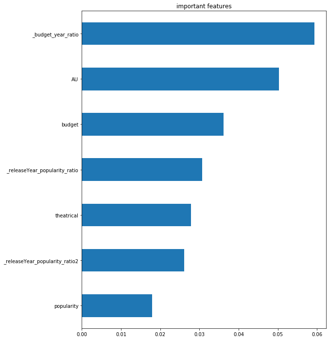

```python
xgbmodel.FI.mean(axis=1).sort_values()[235:250].plot(kind="barh",title = "important features", figsize = (9,12))
```

# 最終分數評估:

```python
train['Revenue_xgb'] = train["xgbfinal"]

print("RMSE model xgb_score :" ,score(train, train.Revenue_xgb))
```

```
RMSE model xgb_score : 2.0973465652418244
```

# 將此檔案上傳至Kaggle，在1000多個隊伍中，排名300多，約在前%26 :

參考文本第55 ~ 56頁:

```python
test['revenue'] =  np.expm1(test["xgbfinal"])
test[['id','revenue']].head()
```

|  | id | revenue |
| --- | --- | --- |
| 3000 | 3001 | 2.572026e+06 |
| 3001 | 3002 | 1.623234e+06 |
| 3002 | 3003 | 3.028727e+06 |
| 3003 | 3004 | 5.964819e+06 |
| 3004 | 3005 | 1.208788e+06 |

# 訓練完成的模型儲存:

```python
import pickle
# 以寫二進制的方式開啟檔案
file = open("xgbmodel.pickle", "wb")
# 把模型寫入到檔案中
pickle.dump(xgbmodel, file)
# 關閉檔案
file.close()
```

[figure not shown]